# Cook Inlet 2021 analysis

31 May 2022

Dataframe ported from the VM for offline analysis…

```r
library(tidyverse)
```

```r
cook.df <- read_csv("../data/CookInlet2021_dataframe.csv") %>%
    mutate(`Sample Code` = ifelse(is.na(`Sample Code`), "pcr_negative", `Sample Code`))
cook.df
```

| Sample_ID | sample | pcr_rep | Sample_Plate | taxon | total_taxon_ct | Sample Code | Sample Label | field_rep | Sample_Date | Metadata Reference |
| --- | --- | --- | --- | --- | --- | --- | --- | --- | --- | --- |
| e00191_1 | e00191 | 1 | YUMI_eDNA_Plate1 | Gadidae | 5 | 202117601 | Prince William Sound | A | 2021-07-04 | Yumi_USGS |
| e00191_1 | e00191 | 1 | YUMI_eDNA_Plate1 | Ammodytidae | 1 | 202117601 | Prince William Sound | A | 2021-07-04 | Yumi_USGS |
| e00191_1 | e00191 | 1 | YUMI_eDNA_Plate1 | Homo_sapiens | 3 | 202117601 | Prince William Sound | A | 2021-07-04 | Yumi_USGS |
| e00191_1 | e00191 | 1 | YUMI_eDNA_Plate1 | Triglops_macellus | 592 | 202117601 | Prince William Sound | A | 2021-07-04 | Yumi_USGS |
| e00192_1 | e00192 | 1 | YUMI_eDNA_Plate1 | Clupeidae | 5 | 202117601 | Prince William Sound | B | 2021-07-04 | Yumi_USGS |
| e00192_1 | e00192 | 1 | YUMI_eDNA_Plate1 | Gadidae | 19 | 202117601 | Prince William Sound | B | 2021-07-04 | Yumi_USGS |
| e00192_1 | e00192 | 1 | YUMI_eDNA_Plate1 | Oncorhynchus | 13 | 202117601 | Prince William Sound | B | 2021-07-04 | Yumi_USGS |
| e00192_1 | e00192 | 1 | YUMI_eDNA_Plate1 | Ammodytidae | 6 | 202117601 | Prince William Sound | B | 2021-07-04 | Yumi_USGS |
| e00192_1 | e00192 | 1 | YUMI_eDNA_Plate1 | Pleuronectidae | 2 | 202117601 | Prince William Sound | B | 2021-07-04 | Yumi_USGS |
| e00192_1 | e00192 | 1 | YUMI_eDNA_Plate1 | Homo_sapiens | 6 | 202117601 | Prince William Sound | B | 2021-07-04 | Yumi_USGS |

[output cut: 990 more lines]

Take a quick look at controls, again.

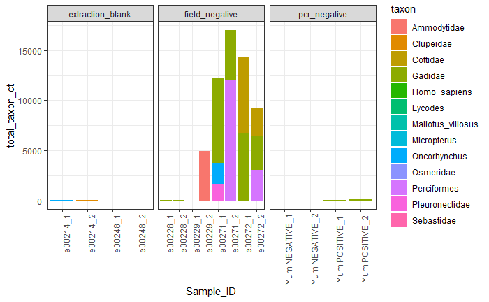

```r
cook.df %>%
  filter(`Sample Code` %in% c("extraction_blank", "field_negative", "pcr_negative") |
           str_detect(Sample_ID, "NEGATIVE")) %>%
  filter(pcr_rep != 3) %>%
  ggplot(aes(x = Sample_ID, y = total_taxon_ct, fill = taxon)) +
  geom_bar(stat = "identity") +
  facet_grid(cols = vars(`Sample Code`), scales = "free") +
  theme_bw() +
  theme(
    axis.text.x = element_text(angle = 90)
  )
```

```r
NA
NA
```

The variation across negatives and pcr replicates is helpful because it suggests that, for example, the Ammodytidae in e00229_2 is introduced in the PCR rather than in the extraction or field sampling because it only shows up in one pcr replicate.

remove the obvious contaminants…

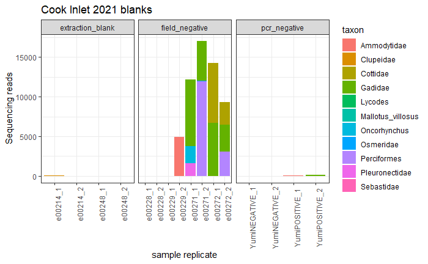

```r
cook.df %>%
  filter(`Sample Code` %in% c("extraction_blank", "field_negative", "pcr_negative") |
           str_detect(Sample_ID, "NEGATIVE")) %>%
  filter(pcr_rep != 3) %>%
  filter(!taxon %in% c("Homo_sapiens", "Micropterus")) %>%
  ggplot(aes(x = Sample_ID, y = total_taxon_ct, fill = taxon)) +
  geom_bar(stat = "identity") +
  facet_grid(cols = vars(`Sample Code`), scales = "free") +
  theme_bw() +
  theme(
    axis.text.x = element_text(angle = 90)
  ) +
  labs(x = "sample replicate",
       y = "Sequencing reads",
       title = "Cook Inlet 2021 blanks")
```

```r
#ggsave("pdf_outputs/blanks.pdf")
```

What remains in the extraction blanks and PCR negatives?

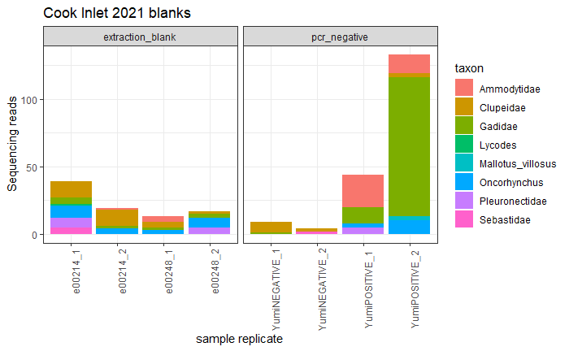

```r
cook.df %>%
  filter(`Sample Code` %in% c("extraction_blank", "pcr_negative") |
           str_detect(Sample_ID, "NEGATIVE")) %>%
  filter(pcr_rep != 3) %>%
  filter(!taxon %in% c("Homo_sapiens", "Micropterus")) %>%
  ggplot(aes(x = Sample_ID, y = total_taxon_ct, fill = taxon)) +
  geom_bar(stat = "identity") +
  facet_grid(cols = vars(`Sample Code`), scales = "free") +
  theme_bw() +
  theme(
    axis.text.x = element_text(angle = 90)
  ) +
  labs(x = "sample replicate",
       y = "Sequencing reads",
       title = "Cook Inlet 2021 blanks")
```

Those are the species I would expect to see because they’re generally found in samples and negative controls for our metabarcoding studies - potentially introduced from lab contamination (esp. prior to purging barcodes/reagents that had been used for other projects).

```r
contam.taxa.to.subtract <- cook.df %>%
  filter(`Sample Code` %in% c("extraction_blank", "pcr_negative") |
           str_detect(Sample_ID, "NEGATIVE")) %>%
  filter(pcr_rep != 3) %>%
  filter(!taxon %in% c("Homo_sapiens", "Micropterus")) %>%
  # maximum number of reads per taxon?
  group_by(taxon) %>%
  summarise(max(total_taxon_ct)) %>%
  rename(reads = `max(total_taxon_ct)`)
```

One way to look at this is the number of reads per each of these taxa. Another way would be the relative proportion of each taxon out of the total reads per sample.

Once we begin digging into the samples, we can get a better handle on which approach is more appropriate.